# Reproducible Research Project 1

```r
NAIndex <- is.na(activity[,1])
sum(is.na(activity$steps))
```

```
## [1] 2304
```

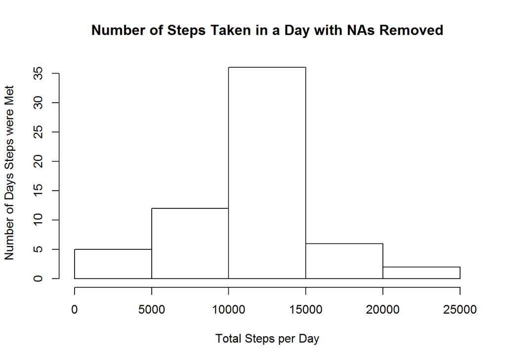

```r
averageSteps <- mean(SPI$steps)

activityNEW <- activity
activityNEW[NAIndex,1] <- averageSteps

totalStepsByDay <- aggregate(steps~date,activityNEW,sum)
hist(totalStepsByDay$steps, xlab="Total Steps per Day", ylab="Number of Days Steps were Met",main= "Number of Steps Taken in a Day with NAs Removed")
```

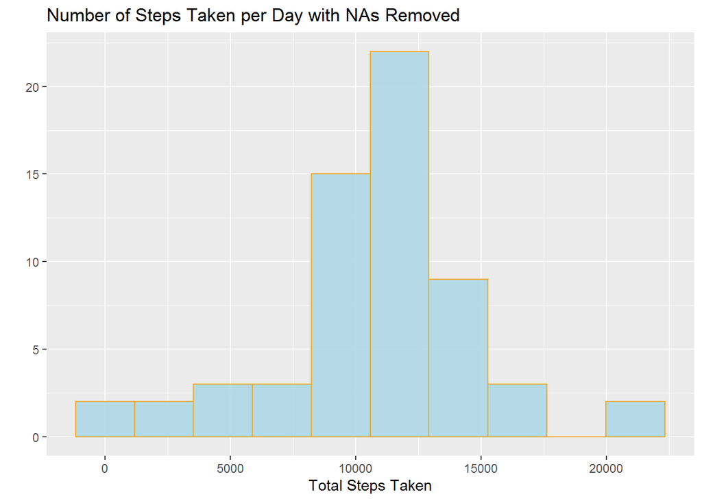

```r
qplot(totalStepsByDay$steps,geom="histogram",bins=10,xlab="Total Steps Taken",main="Number of Steps Taken per Day with NAs Removed", fill=I("lightblue"),col=I("orange"),alpha=I(0.9))
```

```r
meanAfterNAs <- mean(totalStepsByDay$steps)
medianAfterNAs <- median(totalStepsByDay$steps)
```

Finally, we would like to see the difference between weekday and weekend activity. Dates were formatted earlier using lubridate, and we will add a new column to the dataset called “datetype” where each interval is assigned weekend or weekday.

The results are plotted in a line graph. The first plot shows both weekends and weekdays on the same plot, while the second plot displays the results seperately.

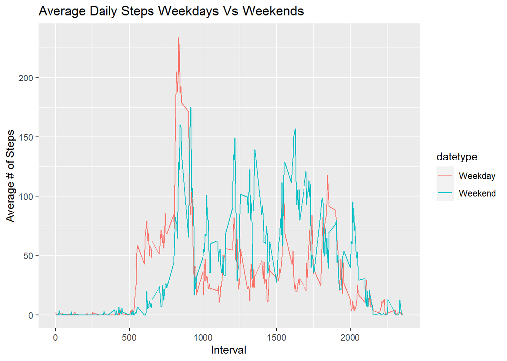

```r
activity$datetype <- sapply(activity$date, function(x){
    if (weekdays(x) =="Sunday" | weekdays(x) == "Saturday")
        {y <- "Weekend"}
    else{y <- "Weekday"}
    y
    })

weekday_weekend_comparison <- aggregate(steps~interval + datetype, activity, mean, na.rm=TRUE)
plot <- ggplot(weekday_weekend_comparison, aes(x=interval, y=steps, color=datetype))+geom_line() + labs(title = "Average Daily Steps Weekdays Vs Weekends", x="Interval", y="Average # of Steps")
plot1 <- ggplot(weekday_weekend_comparison, aes(x=interval, y=steps, color=datetype))+geom_line() + labs(title = "Average Daily Steps Weekdays Vs Weekends", x="Interval", y="Average # of Steps") + facet_wrap(~datetype, ncol=1,nrow=2)
print(plot)
```

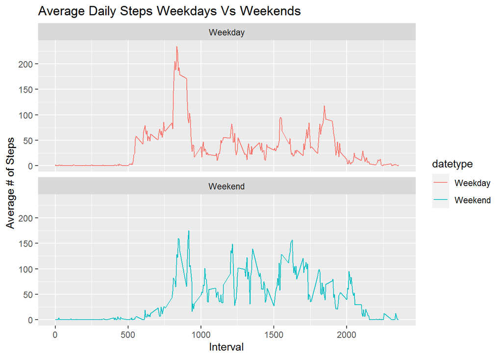

```r
print(plot1)
```